# ch02_03_02_dtreeviz_modelVis_v11_2610

> 🛠️ **2026.10 수정본 (v11)** — 원본: ch02_03_02_dtreeviz_modelVis.ipynb

> dtreeviz 2.x에서는 `from dtreeviz.trees import *`로 `tree`가 딸려 오지 않고, 예전 `dtreeviz()` 함수도 제대로 동작하지 않아요. 그래서 `tree`를 직접 import 하고, 새 방식 `dtreeviz.model(...).view(...)`로 그리는 같은 이름의 `dtreeviz()` 함수를 만들어 아래 셀들은 그대로 쓰게 했어요. 마지막 파일 다운로드는 코랩에서만 되니, 로컬에서는 저장만 하고 넘어가게 `try/except`로 감쌌습니다.

## ch02. 의사결정트리 시각화

### 학습 내용

- 1. 의사결정트리 모델을 시각화를 통해 이해해 봅니다.
- 2. 다양한 데이터 셋을 시각화 해 봅니다.
  - california housing data - 집값 데이터 예측 모델 시각화
  - IRIS 꽃의 종류 예측 모델 시각화
  - 유방암 예측 모델 시각화
  - 당뇨병 진행도 예측 모델 시각화
  - 웹에서 파일 저장해서 확인하기

### 목차

01 시각화 라이브러리 설치  
02 캘리포니아 집값 예측 모델 시각화  
03 IRIS 꽃의 종류 예측 모델 시각화  
04 유방암 예측 모델 시각화  
05 당뇨병 진행도 예측 모델 시각화  
06 웹에서 확인(파일 저장 및 다운로드)

### 01 시각화 라이브러리 설치

목차로 이동하기

```python
import sys
import os

if 'google.colab' in sys.modules:
  !pip install -q dtreeviz
```

### 라이브러리 설치

```python
import sys
import os

# add library module to PYTHONPATH
print(os.getcwd())
sys.path.append(f"{os.getcwd()}/../")
```

```
.
```

```python
from sklearn.datasets import *
from dtreeviz.trees import *
from IPython.display import Image, display_svg, SVG
# 2026.10 수정: dtreeviz 2.x는 trees 모듈 구조가 바뀌어 아래 이름들을 직접 불러와야 함
from sklearn import tree           # DecisionTreeRegressor/Classifier
import numpy as np
import dtreeviz as dtv

# 2026.10 수정: dtreeviz 2.x는 새 방식 dtv.model(...).view(...)로 그림
#   (예전 dtreeviz() 함수는 2.3에서 인자가 어긋나 에러) → 아래 셀들을 그대로 쓰도록 같은 이름의 함수로 감쌈
def dtreeviz(tree_model, X_train, y_train, feature_names=None, target_name=None,
             class_names=None, X=None, **view_options):
    viz_model = dtv.model(tree_model, X_train, y_train, feature_names=feature_names,
                          target_name=target_name, class_names=class_names)
    return viz_model.view(x=X, **view_options)   # title, scale, orientation, fontname 등
```

### 02 캘리포니아 집값 예측 모델 시각화

목차로 이동하기

### 회귀 트리(Regression tree)

- 데이터 셋 : california housing data
- url : [california housing dataset](https://scikit-learn.org/stable/modules/generated/sklearn.datasets.fetch_california_housing.html) (regression).

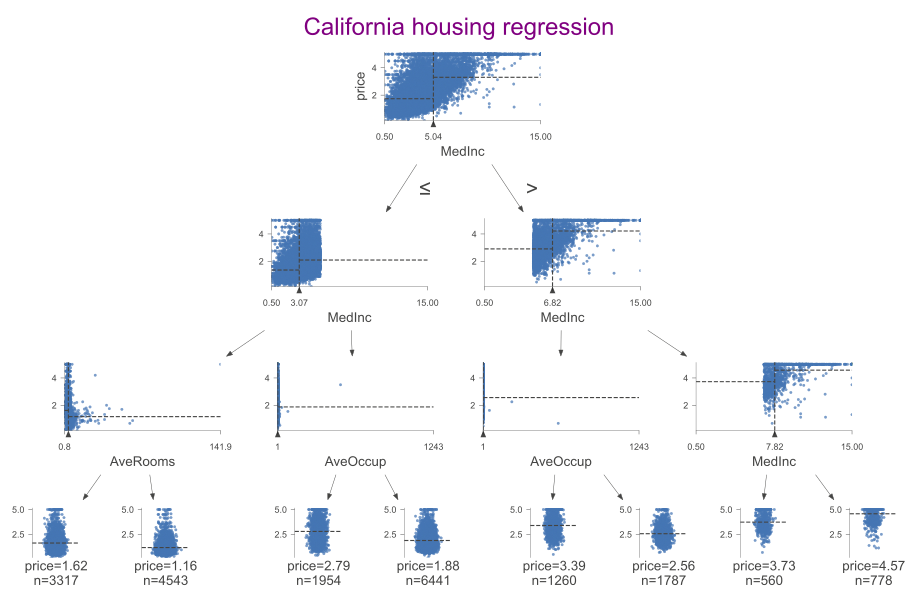

```python
model = tree.DecisionTreeRegressor(max_depth=3)
housing = fetch_california_housing()

# 데이터 나누기
X_train = housing.data
y_train = housing.target

# 모델 학습
model.fit(X_train, y_train)

# 모델 시각화
viz = dtreeviz(model,
               X_train,
               y_train,
               target_name='price',  # leaf node에 보여지는 target 표시
               feature_names=housing.feature_names,
               title="California housing regression",   # 제목
               fontname="Arial",  # 글씨 폰트
               title_fontsize=16,  # 타이틀 폰트 사이즈
               colors = {"title":"purple"}
              )
viz
```

### 이미지 스케일 조정

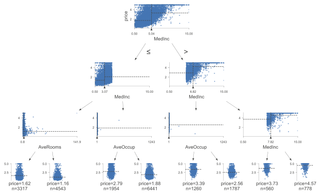

```python
dtreeviz(model,
       X_train,
       y_train,
       target_name='price',  # leaf node에 보여지는 target 표시
       feature_names=housing.feature_names,
       scale=0.7              # scale를 통해 이미지의 크기를 조절
      )
```

### 03 IRIS 꽃의 종류 예측 모델 시각화

목차로 이동하기

### 분류 트리(Classification tree) - 다항분류

```python
model = tree.DecisionTreeClassifier(max_depth=2)


# 데이터 나누기
iris = load_iris()
X_train = iris.data
y_train = iris.target

# 모델 학습
model.fit(X_train, y_train)

# 모델 시각화
viz = dtreeviz(model,
               X_train,
               y_train,
               target_name='iris type',
               fontname="Arial",
               feature_names=iris.feature_names,
               class_names=["setosa", "versicolor", "virginica"],
               histtype= 'barstacked')  # 히스토 그램 형태 : 기본(barstacked)
viz
```

[figure not shown]

### 04 유방암 예측 모델 시각화

목차로 이동하기

[Breast Cancer Wisconsin Dataset](http://archive.ics.uci.edu/ml/datasets/breast+cancer+wisconsin+%28diagnostic%29)

```python
model = tree.DecisionTreeClassifier(max_depth=2)
cancer = load_breast_cancer()

X_train = cancer.data
y_train = cancer.target
model.fit(X_train, y_train)

viz = dtreeviz(model,
               X_train,
               y_train,
               target_name='cancer',
               feature_names=cancer.feature_names,
               class_names=["malignant", "benign"],
               orientation='LR')
viz
```

[figure not shown]

### 05 당뇨병 진행도 예측 모델 시각화

목차로 이동하기

| 컬럼명 | 설명 | 데이터 유형 |
| --- | --- | --- |
| age | 나이 | 숫자 |
| sex | 성별 | 명목형 |
| bmi | 체질량 지수 | 숫자 |
| bp | 평균 혈압 | 숫자 |
| s1 | 혈청 측정값1 | 숫자 |
| s2 | 혈청 측정값2 | 숫자 |
| s3 | 혈청 측정값3 | 숫자 |
| s4 | 혈청 측정값4 | 숫자 |
| s5 | 혈청 측정값5 | 숫자 |
| s6 | 혈청 측정값6 | 숫자 |
| Y | 10개변수 측정 후, 당뇨병 진행도 | 숫자 |

```python
model = tree.DecisionTreeRegressor(max_depth=3)

# 데이터 나누기
diabetes = load_diabetes()
X_train = diabetes.data
y_train = diabetes.target

# 모델 학습
model.fit(X_train, y_train)

X = diabetes.data[np.random.randint(0, len(diabetes.data)),:]

viz = dtreeviz(model,
               X_train,
               y_train,
               target_name='progress',
               feature_names=diabetes.feature_names,
               X=X,
               show_node_labels = True,
               scale=.7
              )
viz
```

[figure not shown]

### 06 웹에서 확인(파일 저장 및 다운로드)

목차로 이동하기

```python
viz.save("decision_tree_diabetes.svg")

try:
    from google.colab import files   # 코랩에서만 동작
    files.download("decision_tree_diabetes.svg")
except ImportError:  # 2026.10 수정: 로컬 주피터에는 google.colab이 없음 → 저장만 하고 넘어감
    print("로컬 실행: 현재 폴더에 저장했습니다 →", "decision_tree_diabetes.svg")
```

```
로컬 실행: 현재 폴더에 저장했습니다 → decision_tree_diabetes.svg
```

### REF

- https://colab.research.google.com/github/parrt/dtreeviz/blob/master/notebooks/examples.ipynb
- https://towardsdatascience.com/4-ways-to-visualize-individual-decision-trees-in-a-random-forest-7a9beda1d1b7

교육용으로 작성된 것으로 배포 및 복제시에 사전 허가가 필요합니다.  
Copyright 2021 LIM Co. all rights reserved.